# R Notebook

# Práctica 06 – Prueba estadística de normalidad en un conjunto de datos con el lenguaje R

Muchas de las pruebas de hipótesis que se hacen en el área de ingeniería asumen que los datos de la variable dependiente tienen una distribución normal, es decir, que la forma en la que sus valores se distribuyen en el plano se ajusta a una campana de Gauss. Por esta razón, una labor importante del ingeniero es determinar si la distribución de una variable experimental es normal o no. Hay dos métodos generalmente aceptados para analizar normalidad, uno es gráfico y otro es usando una prueba de normalidad, de las cuales existen varias. Para ilustrar ambos tipos de análisis trabajaremos con dos data sets en esta práctica.

El primer data set a trabajar almacena información del INEGI, la cual contiene el porcentaje de población económicamente activa, por cuatrimestre, en México desde 2006 hasta 2019. Esa tabla ya la has trabajado en prácticas previas. Antes de abrir el data set, no olvides instalar el paquete para lectura de archivos .xlsx e invocar la librería para su lectura. Usa:

```r
library("readxl")
```

Ahora abre la tabla de datos del INEGI para crear el primer data set en R que analizaremos en la práctica (no olvides cambiar la ruta de acceso a tu archivo):

```r
df_INEGI <- read_excel("C:/Users/juan_/OneDrive - Universidad de Colima/Escritorio/6to/practica 6 normalidad - MdD/datasets/PobOcupada2019Mx_INEGI.xlsx")
```

Ahora analizaremos la posible normalidad de esos datos utilizando el **método gráfico**. En este caso, la idea es graficar la distribución de frecuencias de los datos de la columna Porcentaje del libro de hoja de cálculo datosINEGI.xlsx y dibujar una gráfica de densidad de frecuencias para ver la forma en que se visualiza la distribución, primero debes crear el gráfico de frecuencias con la función hist() y la curva de densidad de frecuencias con la funicón lines :

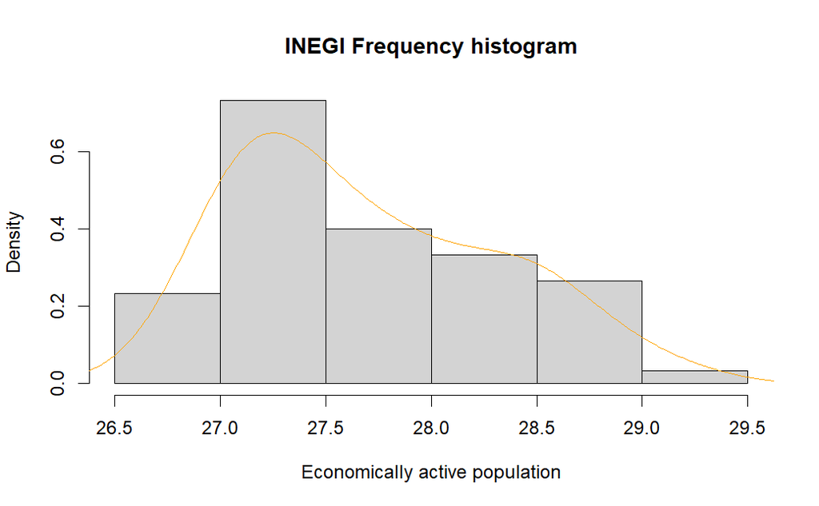

```r
hist(df_INEGI$Porcentaje, probability=T, main="INEGI Frequency histogram", xlab="Economically active population")
lines(density(df_INEGI$Porcentaje), col='orange')
```

Con lo anterior, deberías visualizar algo similar a lo que se muestra en la figura 1. Como puedes ver, la distribución de los datos de la variable porcentaje no se apega a una distribución normal.

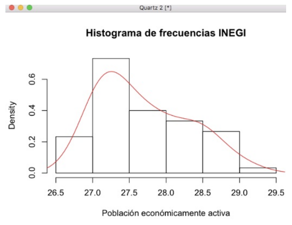

**Figura 1.** Histograma de frecuencias del data set de INEGI.

Ahora analizaremos la distribución utilizando una **prueba de normalidad** llamada Shapiro-Wilks, la cual se basa en la hipótesis nula de que una muestra proviene de una distribución normal. Si no se programa otra cosa, en R el nivel de significancia de esa prueba se fija 0.05. Para realizar entonces la prueba de hipótesis utilizaremos la función shapiro.test() :

```r
shapiro.test(df_INEGI$Porcentaje)
```

```
    Shapiro-Wilk normality test

data:  df_INEGI$Porcentaje
W = 0.94888, p-value = 0.01381
```

Para determinar si el resultado de la prueba Shapiro-Wilk indica la normalidad de la distribución debemos analizar si el valor p obtenido (p-value) supera el nivel de significancia fijado, el cual como indicamos anteriormente es 0.05. Como observas en el resultado del comando, p-value = 0.01381 es menor que 0.05, por lo que se rechaza (o no se acepta) la hipótesis nula y se acepta la hipótesis alterna, determinando que la distribución no es normal. El resultado de este método coincide con lo que observas en la figura 1.

Ahora veamos otro caso. En esta parte de la práctica importaremos una hoja de cálculo con datos de temperatura de un sensor de internet de las cosas que registra temperaturas al interior de un refrigerador. Primero debemos abrir el libro con los datos de temperaturas, que se encuentra en el archivo Temp_data.xlsx para crear un data set en R llamado datosTemp :

```r
df_temperature <- read_excel("C:/Users/juan_/OneDrive - Universidad de Colima/Escritorio/6to/practica 6 normalidad - MdD/datasets/Temp_data.xlsx")
```

Siguiendo con la metodología indicada anteriormente, para analizar la normalidad de un dato, en este caso la columna del dataset llamada gradosC , graficaremos las frecuencias y su curva de densidad para ver el comportamiento. Así, teclea los siguientes dos comandos:

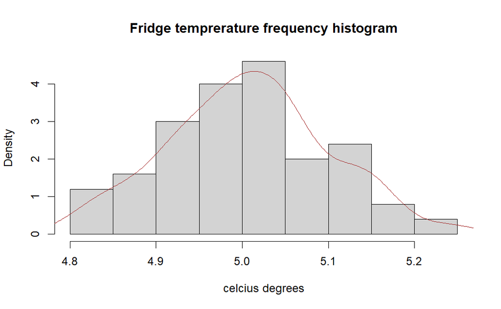

```r
hist(df_temperature$gradosC, probability=T, main="Fridge temprerature frequency histogram", xlab="celcius degrees")
lines(density(df_temperature$gradosC), col='brown')
```

El resultado de los comandos anteriores se ilustra en la figura 2, en la que puede observarse que la distribución de los datos de temperatura se acercan a una distribución normal.

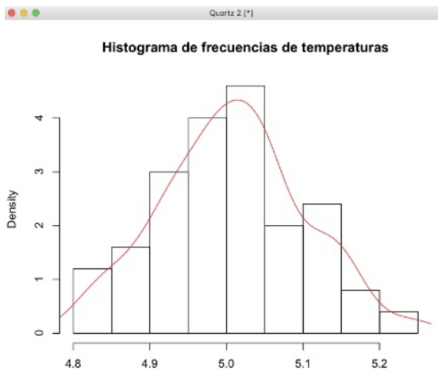

**Figura 2.** Histograma de frecuencias del data set de temperaturas.

Ahora procederemos a hacer el análisis con la prueba de normalidad:

```r
shapiro.test(df_temperature$gradosC)
```

```
    Shapiro-Wilk normality test

data:  df_temperature$gradosC
W = 0.98994, p-value = 0.6599
```

El comando anterior debe mostrarte lo siguiente: Shapiro-Wilk normality test data: datosTemp$gradosC W = 0.98994, p-value = 0.6599

Como observas en el resultado, el p-value = 0.6599 es mayor que el nivel de significancia de 0.05, por lo que se acepta la hipótesis nula de que la distribución es normal.

Ahora que ya has analizado dos data sets para determinar si la distribución de alguna de sus variables es normal, también debes saber que existen otras pruebas para hacer ese tipo de análisis, entre las que se cuentan Kolmogorov-Smirnov, Mann – Whitney, o Kruskal Wallis. Estas se usan de acuerdo a distintas características que puedan presentar los datos los datos.

### Cuestionamiento básico previo a la práctica

**¿Cuál de los métodos, el gráfico o el de prueba de normalidad, es más útil para analizar si la distribución de una variable es o no normal?**

En un caso cerrado sería la prueba de normalidad ya que el método gráfico depende de la subjetivadad de quien evalua la gráfica. Aunque este útlmo es mejor para una comprensión visual rápida de la distribución de datos, pero como dije el método de la prueba de normalidad más riguroso y estadísticamente sólido para evaluar la normalidad.

### Procedimiento o desarrollo

1. Importa el data set Faithful_data.xlsx.

```r
df_volcano <- read_excel("C:/Users/juan_/OneDrive - Universidad de Colima/Escritorio/6to/practica 6 normalidad - MdD/datasets/Faithful_data.xlsx")
```

2. Analiza mediante ambos, el método gráfico y la prueba de normalidad Shapiro-Wilks, la columna waiting de ese data set para determinar si su distribución es normal.

   Método gráfico

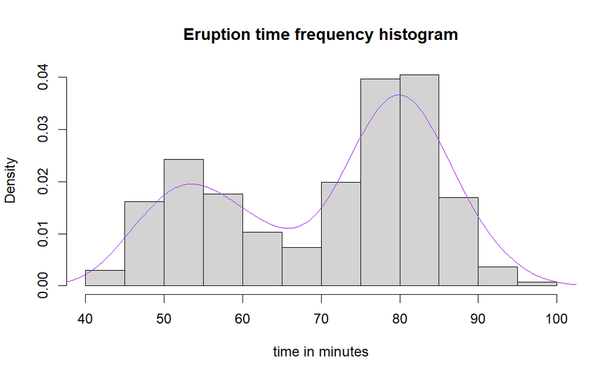

```r
hist(df_volcano$waiting, probability=T, main="Eruption time frequency histogram", xlab="time in minutes")
lines(density(df_volcano$waiting), col='purple')
```

Se puede observar en la gráfica que la distribución no es normal porque no hay una campana de gaus y ni si quiera hay un solo pico de frecuencia. Esto concuerda con la realidad ya que la activadad volcánica de un volcán no se da en patrones muy consistentes

Prueba de normalidad Shapiro-Wilks

```r
shapiro.test(df_volcano$waiting)
```

```
    Shapiro-Wilk normality test

data:  df_volcano$waiting
W = 0.92215, p-value = 1.015e-10
```

El resultado confirma que la distribución de la columna waiting no es normal

### Conclusiones

Como mencioné antes en la práctica los métodos que arrojan resultados cuantitativos arrojan un resultado más fiable cuando hay incertidumbre en el análisis de la gráfica de frecuencias